# hwp2_collins

Author

Caroline Collins

This project uses data from the tidy Tuesday collection on 10/18/2022 and includes two data sets. The first data set includes information about each episode ever released of the Netflix original series “Stranger Things.” The columns include the Season Number, Episode Number, Episode Name, Director Name, Writer Name, and Original Release Date. The second data set, and the one this project focuses on, details all dialogue lines from every episode of the show. Similarly this data set has Season Number and Episode Number, but also includes raw text, line number, stage direction, dialogue, and the start and end times of each line of dialogue.

The main goal of this project will be to see how the dialogue changes throughout the course of the show both within each season and across the airing of the show in general. This will be done through the use of summaries, a tf-idf analysis, sentiment analysisk, and word cloud features.

```r
#install.packages("tidytuesdayR")
library(dplyr)
library(tidyr)
library(ggplot2)
library(tidytext)
tuesdata <- tidytuesdayR::tt_load('2022-10-18')
```

```
--- Compiling #TidyTuesday Information for 2022-10-18 ----
```

```
--- There are 2 files available ---
```

```
--- Starting Download ---
```

```
--- Download complete ---
```

```r
episodes <- tuesdata$episodes
dialogue_st <- tuesdata$stranger_things_all_dialogue
```

Looking into the general dialogue data, there seem to be many rows filled with NA values since the actors aren’t speaking on screen but performing some sort of other action. These rows needs to be removed for the sake of further analysis.

```r
dialogue_st_noNA <- dialogue_st %>%
  filter(!is.na(dialogue))

dialogue_unnest <- dialogue_st_noNA |>
  unnest_tokens(word, dialogue) |>
  anti_join(stop_words)
table(dialogue_unnest$season)
```

```
    1     2     3     4
 7581  8685  9986 16211
```

```r
season1 <- dialogue_unnest %>%
  filter(season == 1)

table(season1$episode)
```

```
   1    2    3    4    5    6    7    8
1182 1083  822  930 1038  938  733  855
```

```r
season2 <- dialogue_unnest %>%
  filter(season == 2)

table(season2$episode)
```

```
   1    2    3    4    5    6    7    8    9
1083 1120 1201  742  980  909  786  767 1097
```

```r
season3 <- dialogue_unnest %>%
  filter(season == 3)

table(season3$episode)
```

```
   1    2    3    4    5    6    7    8
 998 1227 1214 1272 1118 1432 1249 1476
```

```r
season4 <- dialogue_unnest %>%
  filter(season == 4)

table(season4$episode)
```

```
   1    2    3    4    5    6    7    8    9
1833 1902 1608 1859 1520 1784 1693 1695 2317
```

Doing some more basic digging into the data to see some trends, each of the four seasons either has 8 or 9 episodes per season. When totaling the total number of words spoken per season, there is a steady increase between seasons 1, 2, and 3, but there is a sharp increase in the total number of words spoken per season between seasons 3 and 4.

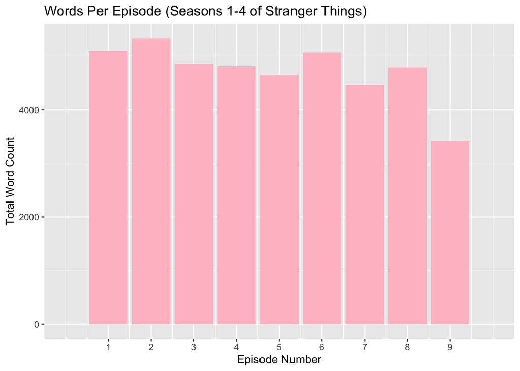

```r
dialogue_summary <- dialogue_unnest %>%
  group_by(episode) %>%
  summarize(word_count = n())

ggplot(dialogue_summary, aes(x = episode, y = word_count)) +
  geom_bar(stat = "identity", fill = "pink") +
  labs(title = "Words Per Episode (Seasons 1-4 of Stranger Things)", x = "Episode Number", y = "Total Word Count")+
  scale_x_continuous(limits = c(0, 10), breaks = 1:9)
```

Looking at some more trends, there seem to be similar amounts of words spoken per episode across all four seasons with 9 as an anomaly since there are only two episode 9’s as compared to the other episode numbers that appear in all four seasons of the show.

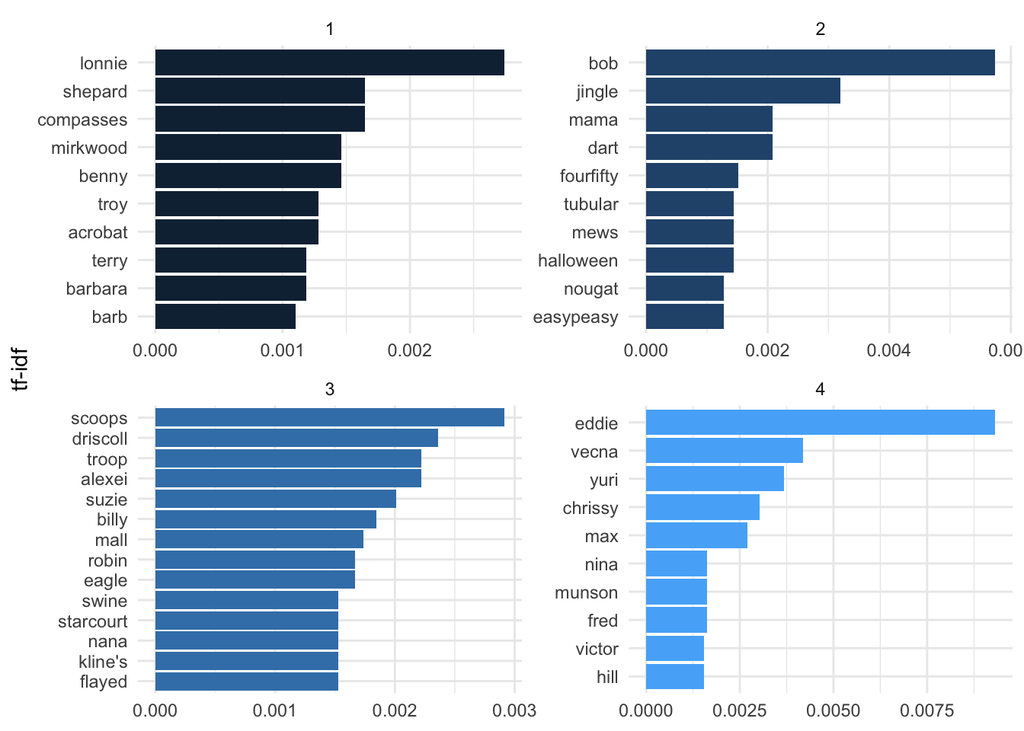

```r
dialogue_freq <- dialogue_unnest |>
  group_by(season)|>
  count(word, sort = TRUE)

dialogue_idf <- dialogue_freq |>
  bind_tf_idf(word, season, n)

dialogue_idf %>%
  group_by(season) %>%
  arrange(desc(tf_idf)) %>%
  top_n(10, tf_idf) %>%
  ggplot(aes(x = tf_idf, y = reorder(word, tf_idf), fill = season)) +
  geom_col(show.legend = FALSE) +
  labs(x = NULL, y = "tf-idf") +
  facet_wrap(~season, scales = "free") +
  theme_minimal()
```

This plot shoes a tf-idf that compares the words between the four seasons. In each season, characters that only appear in that season are high on the tf-idf. For example Barb only appears in season 1 of the show and Vecna only appears in season 4 of the show.

```r
bigrams1 <- dialogue_st_noNA %>%
  filter(season == 1) %>%
  unnest_tokens(bigram, dialogue, token = "ngrams", n = 2)

separate1 <- separate(bigrams1, bigram, c("word1", "word2", sep = " "))
no_stop1 <- separate1 %>%
      filter(!word1 %in% stop_words$word) %>%
      filter(!word2 %in% stop_words$word)

bigram_noNA1 <- no_stop1 %>%
  filter(!is.na(word1)) %>%
  filter(!is.na(word2))

s1_bigram <- bigram_noNA1 %>%
  unite(bigram, word1, word2, sep = " ")

s1_bigram_counts <- s1_bigram %>% count(bigram, sort=TRUE)



bigrams2 <- dialogue_st_noNA %>%
  filter(season == 2) %>%
  unnest_tokens(bigram, dialogue, token = "ngrams", n = 2)

separate2 <- separate(bigrams2, bigram, c("word1", "word2", sep = " "))
no_stop2 <- separate2 %>%
      filter(!word1 %in% stop_words$word) %>%
      filter(!word2 %in% stop_words$word)

bigram_noNA2 <- no_stop2 %>%
  filter(!is.na(word1)) %>%
  filter(!is.na(word2))

s2_bigram <- bigram_noNA2 %>%
  unite(bigram, word1, word2, sep = " ")

s2_bigram_counts <- s2_bigram %>% count(bigram, sort=TRUE)

bigrams3 <- dialogue_st_noNA %>%
  filter(season == 3) %>%
  unnest_tokens(bigram, dialogue, token = "ngrams", n = 2)

separate3 <- separate(bigrams3, bigram, c("word1", "word2", sep = " "))
no_stop3 <- separate3 %>%
      filter(!word1 %in% stop_words$word) %>%
      filter(!word2 %in% stop_words$word)

bigram_noNA3 <- no_stop3 %>%
  filter(!is.na(word1)) %>%
  filter(!is.na(word2))

s3_bigram <- bigram_noNA3 %>%
  unite(bigram, word1, word2, sep = " ")

s3_bigram_counts <- s3_bigram %>% count(bigram, sort=TRUE)

bigrams4 <- dialogue_st_noNA %>%
  filter(season == 4) %>%
  unnest_tokens(bigram, dialogue, token = "ngrams", n = 2)

separate4 <- separate(bigrams4, bigram, c("word1", "word2", sep = " "))
no_stop4 <- separate4 %>%
      filter(!word1 %in% stop_words$word) %>%
      filter(!word2 %in% stop_words$word)

bigram_noNA4 <- no_stop1 %>%
  filter(!is.na(word1)) %>%
  filter(!is.na(word2))

s4_bigram <- bigram_noNA4 %>%
  unite(bigram, word1, word2, sep = " ")

s4_bigram_counts <- s4_bigram %>% count(bigram, sort=TRUE)

s1_first10 <- s1_bigram_counts[1:10, ]
s2_first10 <- s2_bigram_counts[1:10, ]
s3_first10 <- s3_bigram_counts[1:10, ]
s4_first10 <- s4_bigram_counts[1:10, ]

all_bigrams <- cbind(s1_first10, s2_first10, s3_first10, s4_first10)

names(all_bigrams) <- c("S1 Bigrams", "S1 N", "S2 Bigrams", "S2 N", "S3 Bigrams", "S3 N", "S4 Bigrams", "S4 N")

print(all_bigrams)
```

```
        S1 Bigrams S1 N        S2 Bigrams S2 N   S3 Bigrams S3 N
1        whoa whoa   18         shit shit   31    holy shit   21
2      lucas lucas   16           hey hey   26    yeah yeah   20
3        yeah yeah   15         yeah yeah   19      hey hey   17
4          hey hey   14         whoa whoa   16  mind flayer   17
5            el el    6       jingle bell   15 scoops troop   16
6  merry christmas    6 sunflower rainbow   12    wait wait   14
7             8 00    5 breathe sunflower   10   bald eagle   13
8     acting weird    5          code red   10    ice cream   13
9       bad people    5        gonna call   10     code red   12
10  hawkins middle    5         holy shit    9    shit shit   11
        S4 Bigrams S4 N
1        whoa whoa   18
2      lucas lucas   16
3        yeah yeah   15
4          hey hey   14
5            el el    6
6  merry christmas    6
7             8 00    5
8     acting weird    5
9       bad people    5
10  hawkins middle    5
```

```r
dialogue_bigrams <- dialogue_st_noNA %>%
   unnest_tokens(bigram, dialogue, token = "ngrams", n = 2)

bigrams_separate <- separate(dialogue_bigrams, bigram, c("word1", "word2", sep = " "))
bigram_nostop <- bigrams_separate %>%
      filter(!word1 %in% stop_words$word) %>%
      filter(!word2 %in% stop_words$word)

bigram_noNA <- bigram_nostop %>%
  filter(!is.na(word1)) %>%
  filter(!is.na(word2))

st_bigram <- bigram_noNA %>%
  unite(bigram, word1, word2, sep = " ")

st_bigram_counts <- st_bigram %>% count(bigram, sort=TRUE)

head(st_bigram_counts, 10)
```

```
# A tibble: 10 × 2
   bigram           n
   <chr>        <int>
 1 shit shit       82
 2 yeah yeah       82
 3 hey hey         74
 4 holy shit       62
 5 whoa whoa       56
 6 wait wait       44
 7 mind flayer     29
 8 code red        26
 9 jesus christ    26
10 lucas lucas     21
```

This table shows the top ten most spoken bigrams for all four seasons of the show combined.

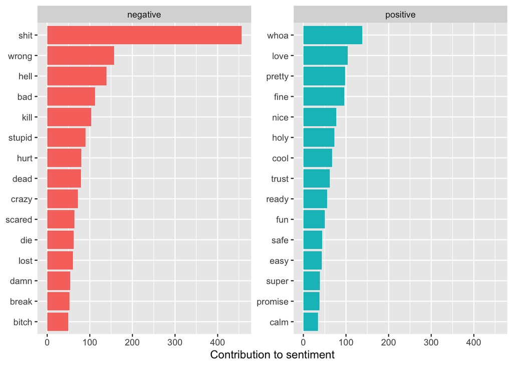

```r
dialogue_sentiment <- dialogue_unnest %>%
  inner_join(get_sentiments("bing"))%>%
  count(word, sentiment, sort = TRUE)%>%
  ungroup()
dialogue_sentiment %>%
  group_by(sentiment) %>%
  slice_max(n, n = 15) %>%
  ungroup() %>%
  mutate(word = reorder(word, n)) %>%
  ggplot(aes(n, word, fill = sentiment)) +
  geom_col(show.legend = FALSE) +
  facet_wrap(~sentiment, scales = "free_y") +
  labs(x = "Contribution to sentiment",
       y = NULL)
```

This plot shows the sentiment analysis from all four seasons of the show. Overall, there seems to be a larger contribution to sentiment from negative words compared to positive words, which is on par with the subject matter of the show.

```r
library(wordcloud)
library(RColorBrewer)
library(wordcloud2)
library(tm)
```

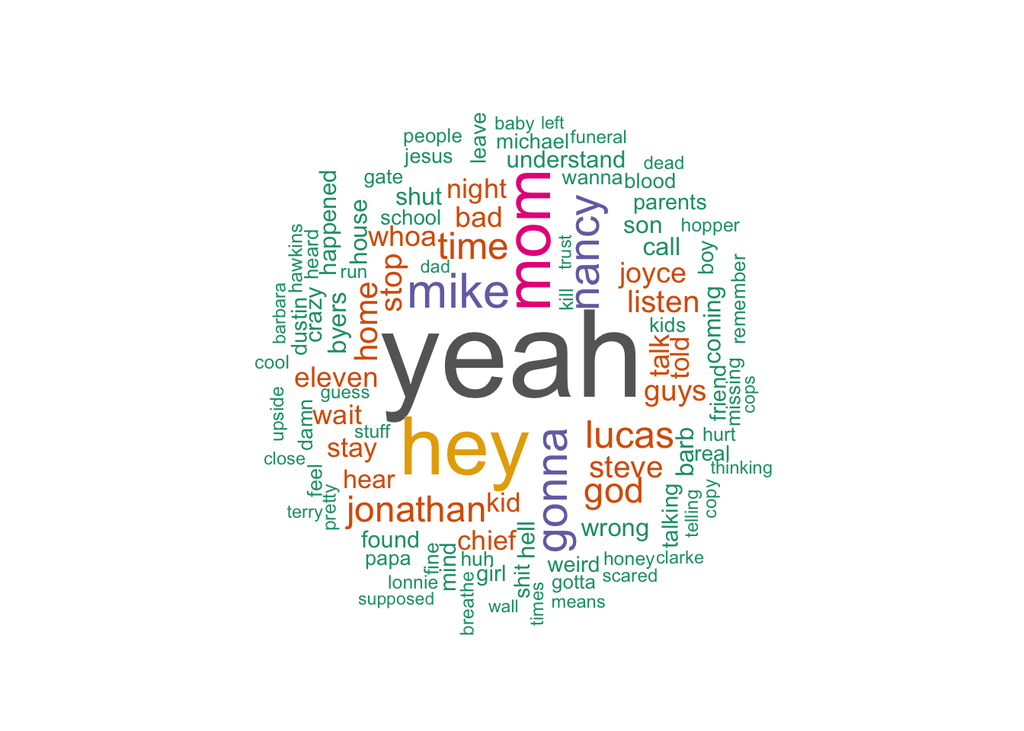

```r
suppressWarnings(
  wordcloud(season1$word
        , scale=c(5,0.5)
        , max.words=100
        , random.order=FALSE
        , rot.per=0.35
        , use.r.layout=FALSE
        , colors=brewer.pal(8, "Dark2")))
```

The above wordcloud represents season 1.

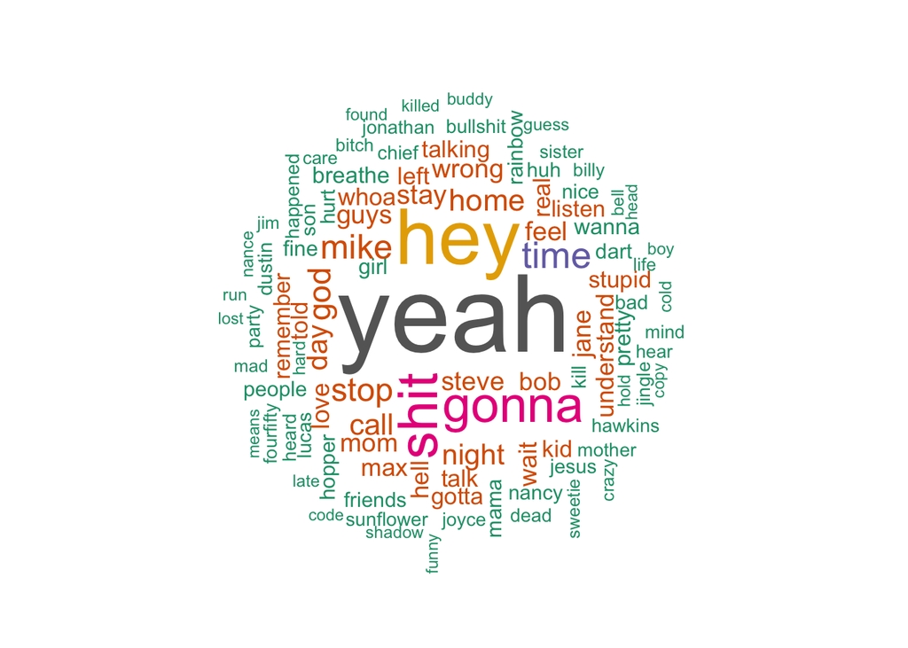

```r
suppressWarnings(
  wordcloud(season2$word
        , scale=c(5,0.5)
        , max.words=100
        , random.order=FALSE
        , rot.per=0.35
        , use.r.layout=FALSE
        , colors=brewer.pal(8, "Dark2")))
```

The above wordcloud represents season 2.

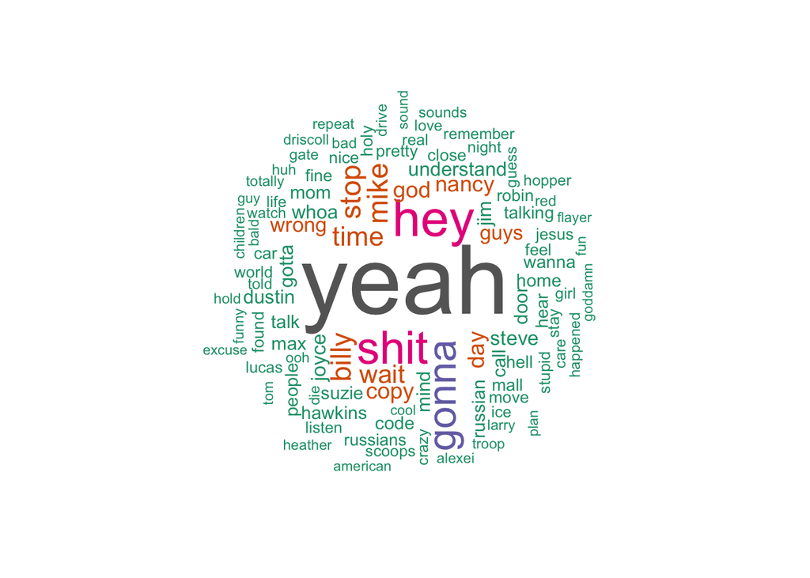

```r
suppressWarnings(
  wordcloud(season3$word
        , scale=c(5,0.5)
        , max.words=100
        , random.order=FALSE
        , rot.per=0.35
        , use.r.layout=FALSE
        , colors=brewer.pal(8, "Dark2")))
```

The above wordcloud represents season 3.

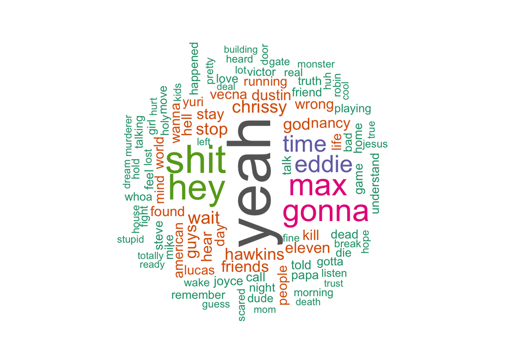

```r
suppressWarnings(
  wordcloud(season4$word
        , scale=c(5,0.5)
        , max.words=100
        , random.order=FALSE
        , rot.per=0.35
        , use.r.layout=FALSE
        , colors=brewer.pal(8, "Dark2")))
```

The above wordcloud represents season 4.

The four above plots are word clouds from the words spoken in seasons 1-4 in order. All four plots seem to have similar “major words” such as yeah and hey. But the lesser used words, similarly seen in the tf-idf, are characters names depending on the season and some seemingly season specific phrasing.